# RMarkdown_MainFile

Amr Attyah

6/15/2019

# Objective

This project is an extension to the Tableau project that has Employee data.

from the exploratory analysis done in Tableau https://public.tableau.com/profile/amr6020#!/,

I have concluded 2 things: 1. Women with technical degrees working in R&D earn more money than men with the same criteria 2. There is a relationship between work-life balance and job satisfaction if the employee was a female working as a sales rep

To be able to make these conclusions, one must use inferential statistcs and see if the averages is significantly different in (1) and see if a relationship (correlation) exists in (2)

BONUS Question

3. I would like to build a machine learning model that aim to predict if an employee is Happy (Job Satisfaction Score = 3,4) or Unhappy (Job Satisfaction Score = 1,2) based on some of the variables in the dataset, and evaluate the performance of the model

```r
setwd("~/Desktop/Data Science (Google)/Other/Data Science Interview/scfhs-project/data")

emp <- read.csv("employees_data.csv")
library(sqldf)
library(corrplot)
library(caret)
```

# Collect data with SQL

## Data will be used to answer Question 1.

```r
# I am trying to get the monthly incomes of technical degrees working in R&D
data.1 <- sqldf('SELECT Gender, MonthlyIncome
                FROM emp
                WHERE Department = "Research & Development"
                AND EducationField = "Technical Degree"')
```

## Data will be used to answer Question 2.

```r
# here I am getting work life balance and job satisfaction score for Females working as Sales Reps
# so we can figure out the correlation between them
data.2<- sqldf('SELECT WorkLifeBalance, JobSatisfaction
                FROM emp
                WHERE Gender = "Female"
                AND JobRole = "Sales Representative"')
```

Data will be used to answer Question 3. The data used for question 3 is the same as the original 1470 record dataset However, there are some cleaning that needs to be made to ensure that that the model is not misleading

# Data Exploration and Data Cleaning

## For Question 1

```r
males = which(data.1$Gender=='Male')
females = which(data.1$Gender=='Female')
t.test(data.1$MonthlyIncome[males],data.1$MonthlyIncome[females])
```

```
##
##  Welch Two Sample t-test
##
## data:  data.1$MonthlyIncome[males] and data.1$MonthlyIncome[females]
## t = -3.2278, df = 52.487, p-value = 0.002152
## alternative hypothesis: true difference in means is not equal to 0
## 95 percent confidence interval:
##  -5021.590 -1172.011
## sample estimates:
## mean of x mean of y
##  4574.810  7671.611
```

P Value = 0.002 (with alpha = 0.05) we reject the null and conclude that the pay is significantly different

## For Question 2

```r
M = cor(data.2)
M # the correlation coefficient = -0.22
```

```
##                 WorkLifeBalance JobSatisfaction
## WorkLifeBalance        1.000000       -0.221942
## JobSatisfaction       -0.221942        1.000000
```

## Exploratory Analysis/Data Cleaning For Question 3

The first step in data cleaning is checking if there are missing values

```r
sum(is.na(emp))
```

```
## [1] 0
```

removed varibles that does not add value or might hurt the model that includes EmployeeCount, EmployeeNumber (ID),Over18 ,StandardHours

```r
data.3<- emp[,-c(9,10)]
```

There are also varibles that seem to have the same value repeated for most rows We can used Near Zero Variance to detect those varibles and remove them Applying the near zero variance on every column in that data frame will help us detect the variables

```r
apply(X = data.3, FUN = nearZeroVar, MARGIN = 2)
```

```
## $Age
## integer(0)
##
## $Attrition
## integer(0)
##
## $BusinessTravel
## integer(0)
##
## $DailyRate
## integer(0)
##
## $Department
## integer(0)
##
## $DistanceFromHome
## integer(0)
##
## $Education
## integer(0)
##
## $EducationField
## integer(0)
##
## $EnvironmentSatisfaction
## integer(0)
##
## $Gender
## integer(0)
##
## $HourlyRate
## integer(0)
##
## $JobInvolvement
## integer(0)
##
## $JobLevel
## integer(0)
##
## $JobRole
```

[output cut: 43 more lines]

```
##
## $WorkLifeBalance
## integer(0)
##
## $YearsAtCompany
## integer(0)
##
## $YearsInCurrentRole
## integer(0)
##
## $YearsSinceLastPromotion
## integer(0)
##
## $YearsWithCurrManager
## integer(0)
```

```r
# it looks like StandardHours, Over18 has the same values across all rows, so we remove them
data.3<- data.3[,-c(20,25)]
```

Multicollinearity is another issues that needs to be looked at it is when the variables (Features) are correlated with each other Therefore it is important to remove one of the correlated variables or apply models that handles such scenarios.

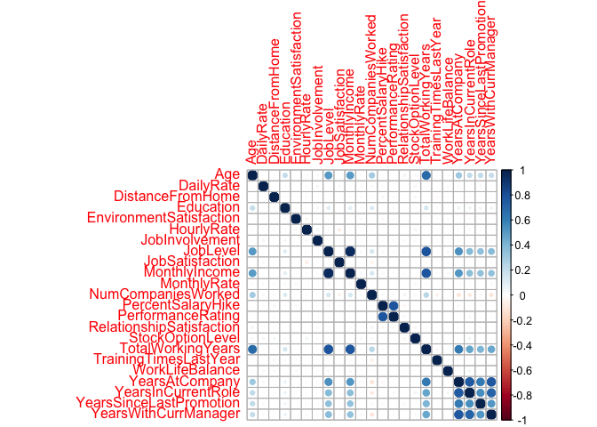

```r
data.3.num = data.3[,-c(2,3,5,8,10,14,16,20)]
M2 = cor(data.3.num)
corrplot(M2, method = "circle")
```

There seems to be some correlated features that needs to be removed

TotalWorkingYears ~ Age , TotalWorkingYears ~ JobLevel MonthlyIncome ~ JobLevel, PerformanceRating ~ PercentSalaryHike So here I will remove Age, JobLevel, and PercentSalaryHike

```r
data.3 = data.3[,-c(1,13,21,28)]
```

Here I am converting 1 & 2 to unhappy employees, and 3 &4 to happy to make modeling binary and cleaner and much more interpretable

```r
data.3$JobSatisfaction[data.3$JobSatisfaction==1 | data.3$JobSatisfaction==2]<-"Unappy"
data.3$JobSatisfaction[data.3$JobSatisfaction==3 | data.3$JobSatisfaction==4]<-"Happy"
```

now that the data is ready, we can start modeling

# Modeling (For Question 3 only)

I will build a Random Forest Model using the Caret Library Before doing this I need to split the data intro training and testing

```r
set.seed(1)

n <- nrow(data.3)
t <- 0.8*n            #Set the size of the training set
set.seed(1)        #Setting a fix seed to make the results reproducible
trainIndex <- sample(1:n,t)

# Training Dataset
training<- data.3[trainIndex,]
training$JobSatisfaction<-as.factor(training$JobSatisfaction)
# Testing Dataset
testing<- data.3[-trainIndex,]
testing$JobSatisfaction<-as.factor(testing$JobSatisfaction)
```

```r
# to help reduce the variance, I will use 10 fold cross validation

train_control<- trainControl(method="cv", number=10)

# train the model
clasmodel<- train(JobSatisfaction~., data=training, trControl=train_control, method="rf")
```

now we can evaluate it against the testing dataset

```r
# make predictions
predictions<- predict(clasmodel,testing)


# append predictions
mydat<- cbind(testing,predictions)

# Confusion Matrix
confusionMatrix(predictions,testing$JobSatisfaction)
```

```
## Confusion Matrix and Statistics
##
##           Reference
## Prediction Happy Unappy
##     Happy    172    114
##     Unappy     7      1
##
##                Accuracy : 0.5884
##                  95% CI : (0.5298, 0.6452)
##     No Information Rate : 0.6088
##     P-Value [Acc > NIR] : 0.7818
##
##                   Kappa : -0.0365
##  Mcnemar's Test P-Value : <2e-16
##
##             Sensitivity : 0.960894
##             Specificity : 0.008696
##          Pos Pred Value : 0.601399
##          Neg Pred Value : 0.125000
##              Prevalence : 0.608844
##          Detection Rate : 0.585034
##    Detection Prevalence : 0.972789
##       Balanced Accuracy : 0.484795
##
##        'Positive' Class : Happy
##
```

# Summarize your results

## For Question 1

Females working for R&D with technical degrees earn an average of $7671 While males working for R&D with technical degrees earn an average of $4574 In our analysis I conducted a T test to see if the difference is statisticly significant The results showed that with a P value of 0.002 we can comfortably say that women working for R&D with technical degrees earn more than men with the same criteria

## For Question 2

The correlation coefficient was -0.22. The closer the number in magnitude to 0 The less the more you know that there is no relationship In this case, although the Tableau treemap suggested that there might be a a relationship between work-life balance and job satisfaction for female working as sales rep, there is not enough evidance to support that claim statisticaly

## For Question 3

Unfortuantly the model have showed it is not the most accurate with a value of 0.5884 While it was able to detect the satisfied “Happy” employees almost perfectly (out of the 179, it predicted 172 correctly), it missed almost all of the unsatisfied “Unhappy” employees (out of the 115, it predicted 1 correctly)

I think some models might perform better, but I think the main issue is the variables used. if a feature selection step was made, I would have had a better model